# Predicting Total Energy Yield of a Gas Turbine

## Phase 1: Data preparation and Visualisation

### Group name: Group 91

### Student name and ID: Souvik Ghosh (s3886205)

1. **Introduction**  
   1.1. Dataset Source  
   1.2. Dataset Details  
   1.3. Dataset Features  
   1.4. Target Feature
2. **Objective For the Project**
3. **Data Preprocessing and Cleaning**
4. **Exploratory Data Analysis Through Visualisation**  
   3.1. Univariate Plots  
   3.2. Bivariate Plots
5. **Conclusions**
6. **References**

## Introduction

### Dataset Source

The dataset used for this project was taken from the UCI machine learning repository (Heysem Kaya, 2022). It contains various measurements taken from different sensors located in a gas turbine in Turkey to study the emissions of carbon monoxide and nitrogen oxides. The recordings in the datset were taken in the year 2015.

### Dataset Details

The dataset contains information on the total yeild energy of a gas turbine located in Turkey. The gas turbine was used to measure the flue gas emissions, i.e. a mix of carbon monoxide and nitrogen oxides.

The datset has attributes such as atmospheric temperature, ambient pressure, ambient humidity, gas turbine inlet and exhaust pressures, and much more. All the readings show the changes in the variables during one hour of operation of the turbine.

This dataset has readings taken from various sensors in the year 2015. It has 7384 observations and 11 variables.

#### Initialisation

- Importing important libraries required for this project
- Reading the datset correctly

```python
import warnings
warnings.filterwarnings("ignore")


import numpy as np
import pandas as pd

import matplotlib.pyplot as plt
import seaborn as sns
%matplotlib inline
%config InlineBackend.figure_format = 'retina'
plt.style.use("seaborn")
```

```python
#loading the dataset and checking the head of the same to see if it has been loaded in properly
GT_emissions = pd.read_csv("gt_2015.csv")
GT_emissions.head()
```

|  | AT | AP | AH | AFDP | GTEP | TIT | TAT | TEY | CDP | CO | NOX |
| --- | --- | --- | --- | --- | --- | --- | --- | --- | --- | --- | --- |
| 0 | 1.95320 | 1020.1 | 84.985 | 2.5304 | 20.116 | 1048.7 | 544.92 | 116.27 | 10.799 | 7.4491 | 113.250 |
| 1 | 1.21910 | 1020.1 | 87.523 | 2.3937 | 18.584 | 1045.5 | 548.50 | 109.18 | 10.347 | 6.4684 | 112.020 |
| 2 | 0.94915 | 1022.2 | 78.335 | 2.7789 | 22.264 | 1068.8 | 549.95 | 125.88 | 11.256 | 3.6335 | 88.147 |
| 3 | 1.00750 | 1021.7 | 76.942 | 2.8170 | 23.358 | 1075.2 | 549.63 | 132.21 | 11.702 | 3.1972 | 87.078 |
| 4 | 1.28580 | 1021.6 | 76.732 | 2.8377 | 23.483 | 1076.2 | 549.68 | 133.58 | 11.737 | 2.3833 | 82.515 |

Let us now check the shape of the dataset. This will give us an idea about the size of the whole dataset.

```python
GT_emissions.shape
```

```
(7384, 11)
```

We can see that the dataset is quite large and has 7384 rows.

### Dataset Features

Tabulating the datset features for a better understanding of the dataset and its variables. The following descriptions are taken from the source of the dataset which is the UCI Machine Learning Repository.

```python
#Tabulating the dataset
from tabulate import tabulate

table = [['Name', 'Description', 'Units'],
        ['AT', 'Ambient Temperature','Celsius'],
        ['AP', 'Ambient Pressure','mbar'],
        ['AH', 'Ambient Humidity', '%'],
        ['AFDP', 'Air Filter Difference Pressure', 'mbar'],
        ['GTEP', 'Gas Turbine Exhaust Pressure', 'mbar'],
        ['TIT', 'Turbine Inlet temperature', 'Celsius'],
        ['TAT', 'Turbine After temperature', 'Celsius'],
        ['TEY', 'Turbine Energy Yield', 'Megawatt hour (MWH)'],
        ['CDP', 'Compressor Discharge Pressure', 'mbar'],
        ['CO', 'Carbon monoxide content','mg/m3'],
        ['NOX', 'Nitrogen oxides content', 'mg/mg3']]

print(tabulate(table, headers='firstrow', tablefmt='fancy_grid'))
```

```
╒════════╤════════════════════════════════╤═════════════════════╕
│ Name   │ Description                    │ Units               │
╞════════╪════════════════════════════════╪═════════════════════╡
│ AT     │ Ambient Temperature            │ Celsius             │
├────────┼────────────────────────────────┼─────────────────────┤
│ AP     │ Ambient Pressure               │ mbar                │
├────────┼────────────────────────────────┼─────────────────────┤
│ AH     │ Ambient Humidity               │ %                   │
├────────┼────────────────────────────────┼─────────────────────┤
│ AFDP   │ Air Filter Difference Pressure │ mbar                │
├────────┼────────────────────────────────┼─────────────────────┤
│ GTEP   │ Gas Turbine Exhaust Pressure   │ mbar                │
├────────┼────────────────────────────────┼─────────────────────┤
│ TIT    │ Turbine Inlet temperature      │ Celsius             │
├────────┼────────────────────────────────┼─────────────────────┤
│ TAT    │ Turbine After temperature      │ Celsius             │
├────────┼────────────────────────────────┼─────────────────────┤
│ TEY    │ Turbine Energy Yield           │ Megawatt hour (MWH) │
├────────┼────────────────────────────────┼─────────────────────┤
│ CDP    │ Compressor Discharge Pressure  │ mbar                │
├────────┼────────────────────────────────┼─────────────────────┤
│ CO     │ Carbon monoxide content        │ mg/m3               │
├────────┼────────────────────────────────┼─────────────────────┤
│ NOX    │ Nitrogen oxides content        │ mg/mg3              │
╘════════╧════════════════════════════════╧═════════════════════╛
```

### Target Feature

The target feature for this project will be the prediction of Turbine Energy Yeild (TEY) which is calculated in Megawatt hour. Descriptive variables from the datset will be used to predict the Turbine Energy Yeild of a gas turbine.

## Objective For The Project

There is an increasing demand for energy. To meet the growing demands, companies have to come up with innovative solutions which can have adverse affects on the environment. Growing demand of power has to be met with how efficiently the power is produced. Accurately predicting the Total Energy Yield will help maintain and optimise conditions that can give the highest yield in the most efficient way.

## Data Preprocessing and Cleaning

The necessary steps taken to preprocess and clean the data are mentioned below:

- Checking for any irrelevant features in the dataset and dropping them
- Checking for null / missing values
- Remove all rows with missing values
- Check for different data types

#### Checking the dataset for irrelevant features

```python
GT_emissions.columns
```

```
Index(['AT', 'AP', 'AH', 'AFDP', 'GTEP', 'TIT', 'TAT', 'TEY', 'CDP', 'CO',
       'NOX'],
      dtype='object')
```

There is no specific column which can be dropped now without doing any furhter analysis. Everything has its unique value. Therefore, for this step, no variables are droppped.

#### Checking for null / missing values

```python
#Sum of all null values
GT_emissions.isnull().sum()
```

```
AT      0
AP      0
AH      0
AFDP    0
GTEP    0
TIT     0
TAT     0
TEY     0
CDP     0
CO      0
NOX     0
dtype: int64
```

As we can see from above, there are no null values present in any variable in the dataset. Dropping of observations is therefore not required.

#### Removing all rows with missing values

Since the dataset does not have any missing or null values present, no observation is removed.

```python
#If any null values were present, removing of observations could have been carried out using the following line of code:
#GT_emissions = GT_emissions.dropna()   ##This will remove all null values. Since we do not have any null values in the dataset, this code is not immplemented
```

#### Checking for different data types

This check is done to ensure all variables have the correct intended data types

```python
#Data types
GT_emissions.dtypes
```

```
AT      float64
AP      float64
AH      float64
AFDP    float64
GTEP    float64
TIT     float64
TAT     float64
TEY     float64
CDP     float64
CO      float64
NOX     float64
dtype: object
```

#### Summary Statistics

Since all the variables in the dataset are numerical, we can use summary statistics to get a gist of information about the dataset.

```python
#Summary statistics
GT_emissions.describe().transpose()
```

|  | count | mean | std | min | 25% | 50% | 75% | max |
| --- | --- | --- | --- | --- | --- | --- | --- | --- |
| AT | 7384.0 | 17.225259 | 8.095783 | -6.2348 | 11.073250 | 17.4565 | 23.684750 | 37.1030 |
| AP | 7384.0 | 1014.509110 | 6.895430 | 989.4000 | 1009.675000 | 1014.0000 | 1018.300000 | 1036.6000 |
| AH | 7384.0 | 68.647464 | 13.541116 | 24.0850 | 59.447250 | 70.9520 | 79.653750 | 96.6660 |
| AFDP | 7384.0 | 3.598909 | 0.610226 | 2.3688 | 3.117300 | 3.5385 | 4.194825 | 5.2395 |
| GTEP | 7384.0 | 26.130149 | 4.473737 | 17.6980 | 23.147000 | 25.3310 | 30.018250 | 40.7160 |
| TIT | 7384.0 | 1078.974689 | 19.762449 | 1016.0000 | 1070.500000 | 1080.3000 | 1099.900000 | 1100.4000 |
| TAT | 7384.0 | 546.642484 | 5.489066 | 516.0400 | 544.747500 | 549.7200 | 550.030000 | 550.5900 |
| TEY | 7384.0 | 133.993380 | 16.179208 | 100.0200 | 126.255000 | 131.6000 | 147.160000 | 179.5000 |
| CDP | 7384.0 | 12.097025 | 1.136601 | 9.8708 | 11.465750 | 11.9330 | 13.148000 | 15.1590 |
| CO | 7384.0 | 3.129986 | 2.234962 | 0.2128 | 1.808175 | 2.5334 | 3.702550 | 41.0970 |
| NOX | 7384.0 | 59.890509 | 11.132464 | 25.9050 | 52.399000 | 56.8385 | 65.093250 | 119.6800 |

We can now reconfirm that there are no missing values in any of the variables (This can be seen in the first column. The count for all variables are the same) and therefore no dropping of observations will be necessary. Let us now proceed to the visualisations to see if we can observe anything interesting.

## Exploratory Data Analysis through Visualisation

The data pre processing is now complete and the dataset is clean to proceed with further analysis. We will be using various graphs to understand the data better.

### Univariate plots

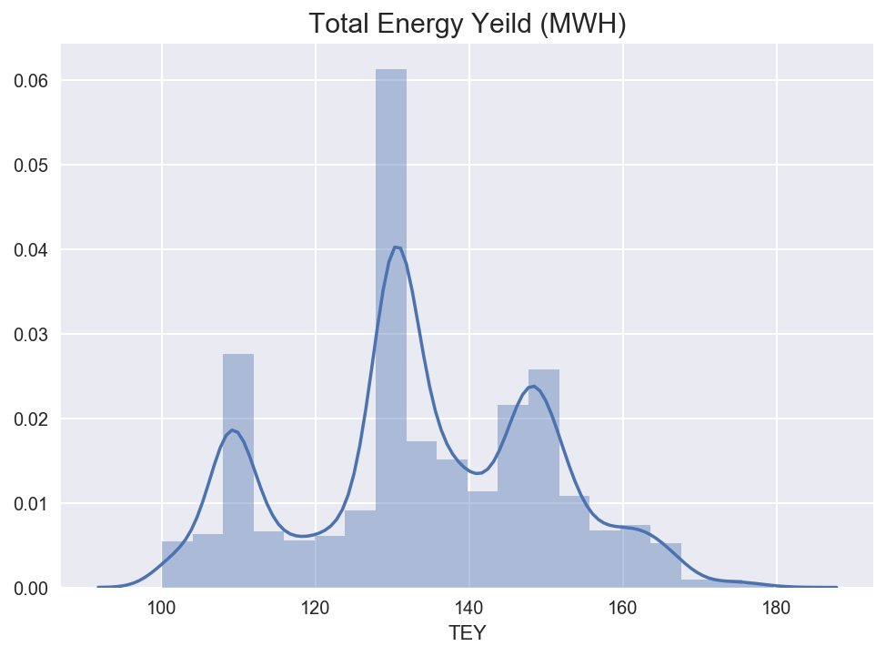

```python
#Checking the distribution of the variable Total Yeild Energy (TEY)
sns.distplot(GT_emissions['TEY'], kde=True, bins=20).set_title('Total Energy Yeild (MWH)', fontsize = 15)
plt.show();
```

According to the graph, we can see that the highest yield can be seen in the 130 MWH mark. This shows that in most conditions, the turbine can yield the said amount of energy. This result was also seen in the summary statistics as the mean TEY was 134 MWH.

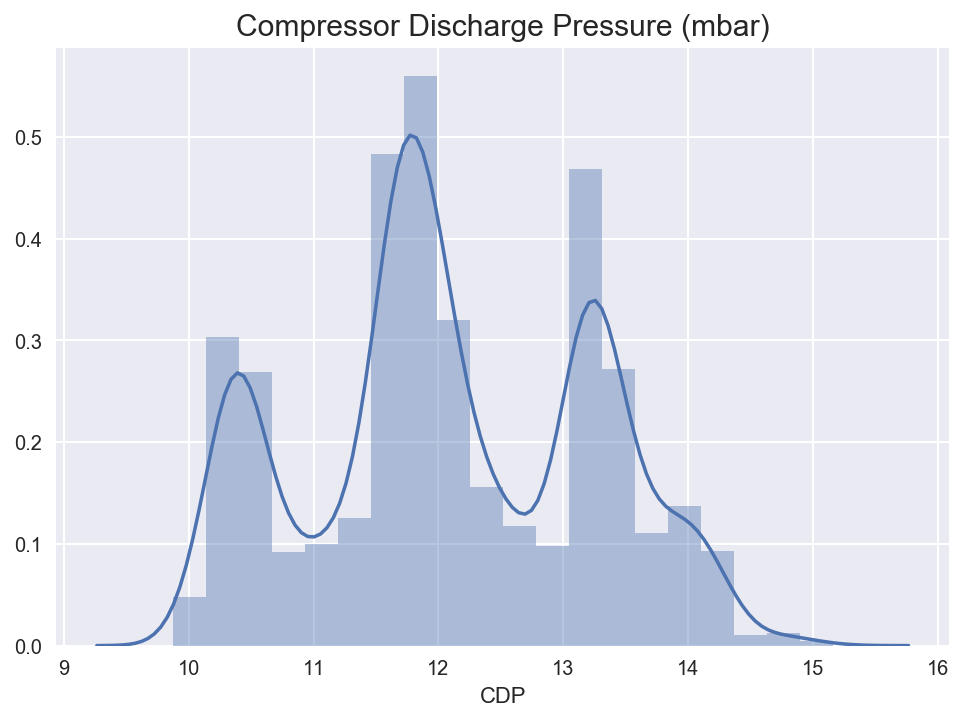

```python
sns.distplot(GT_emissions['CDP'], kde=True, bins=20).set_title('Compressor Discharge Pressure (mbar)', fontsize = 15)
plt.show();
```

From the graph above, we can see that it follows a similar pattern as TEY. This means there is some correlation between the two variables. we can further look at the correlations during the bivariate plots.

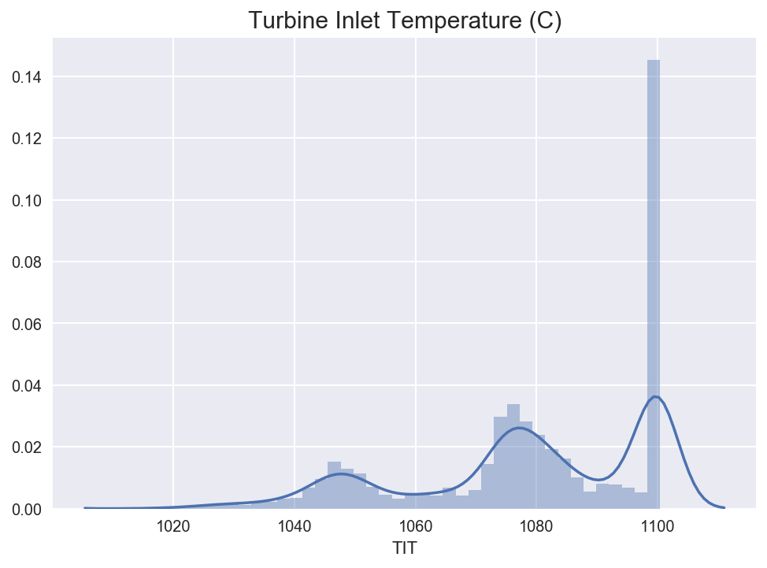

```python
sns.distplot(GT_emissions['TIT'], kde=True, bins=40).set_title('Turbine Inlet Temperature (C)', fontsize = 15)
plt.show();
```

Gas turbines usually have the highest efficiency when the inlet temperature is high. However, this graph does not compare with the mean we got from summary statistics. This needs to be investigated further. We can clearly see a high peak at around 1100 degrees, but the mean for this variable is 1079 degrees. The lower section of the graph could also be due to the presence of outliers which we will be looking at using boxplots.

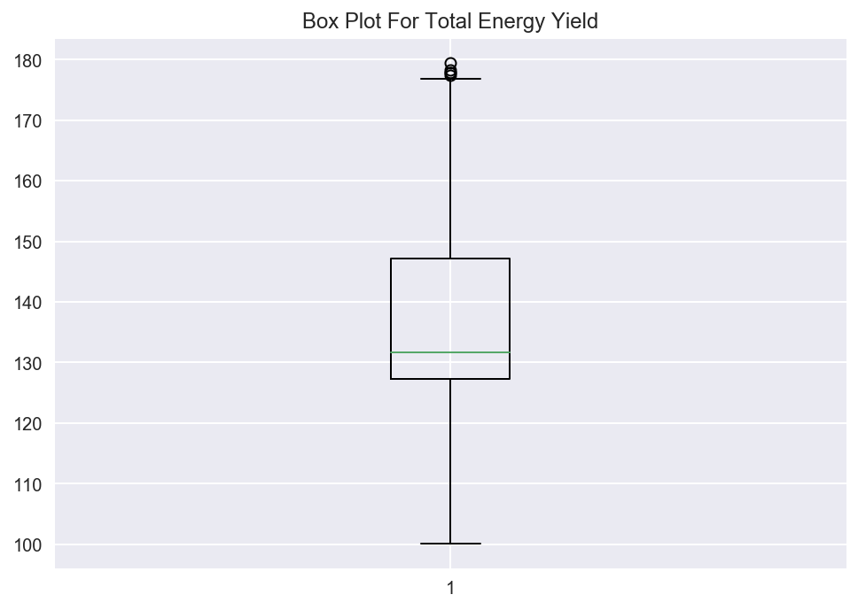

```python
#Box plot for TEY
plt.boxplot(GT_emissions['TEY'])
plt.title('Box Plot For Total Energy Yield')
```

There are some values that are lying outside the boxplot. However, we do not have enough evidence to suggest that they might be potential outliers.

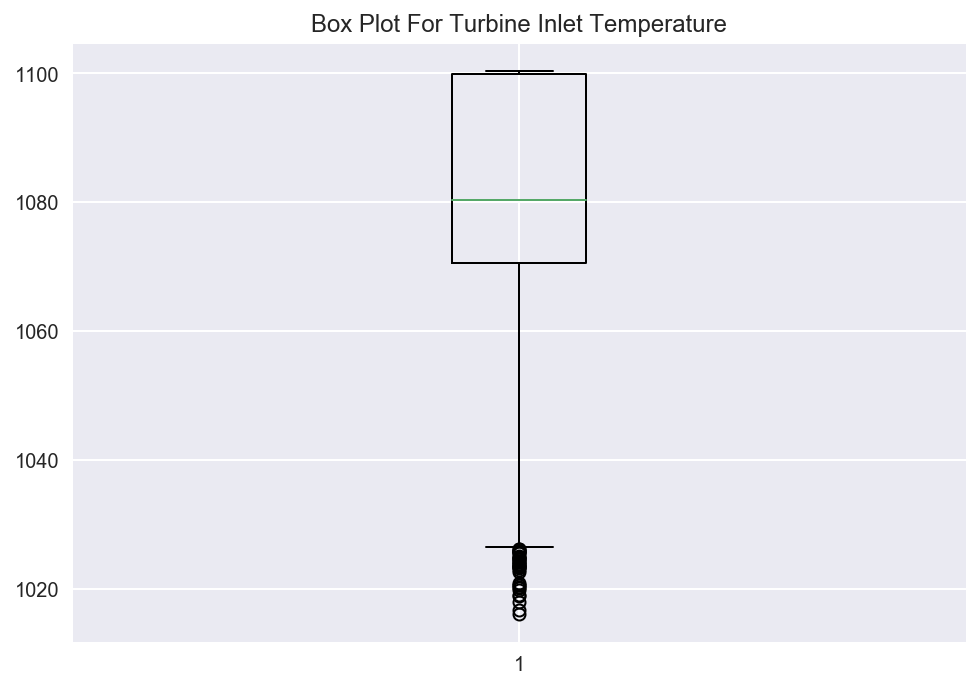

```python
#Box plot for TIT
plt.boxplot(GT_emissions['TIT'])
plt.title('Box Plot For Turbine Inlet Temperature')
```

```python
GT_emissions.drop(GT_emissions[GT_emissions['TIT'] <= 1030].index, inplace = True)
GT_emissions.shape
```

```
(7299, 11)
```

Looking at the boxplot, we can assume that there might be certain potential outliers present in this variable. Therefore, treating the outliers is an important step for any machine learning problem as it might affect teh accuracy of the program later on.

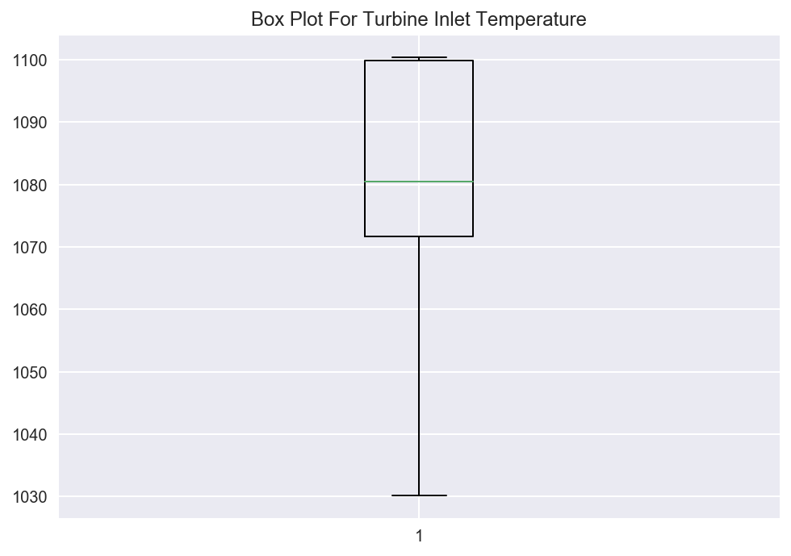

```python
#Checking after removal of outliers
plt.boxplot(GT_emissions['TIT'])
plt.title('Box Plot For Turbine Inlet Temperature')
```

The outliers are now removed. Let us now move on to bivariate plots for further analysis.

### Bivariate Plots

For Bivaraite plots, we will be comparing TEY against TIT, CDP, AFDP, GTEP, AP, and AT. According to research, the total energy yield (TEY) is mostly affected by the above mentioned variables.

[figure not shown]

```python
#Scatter plot between TEY and TIT
plt.scatter(GT_emissions['TEY'], GT_emissions['TIT'])
plt.xlabel('Total Energy Yield in MWH')
plt.ylabel('Turbine Inlet Temperature in C')
```

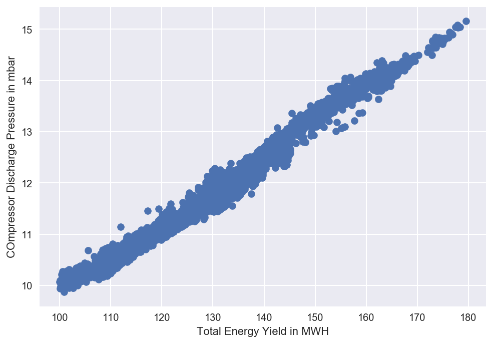

```python
#Scatter plot between TEY and CDP
plt.scatter(GT_emissions['TEY'], GT_emissions['CDP'])
plt.xlabel('Total Energy Yield in MWH')
plt.ylabel('COmpressor Discharge Pressure in mbar')
```

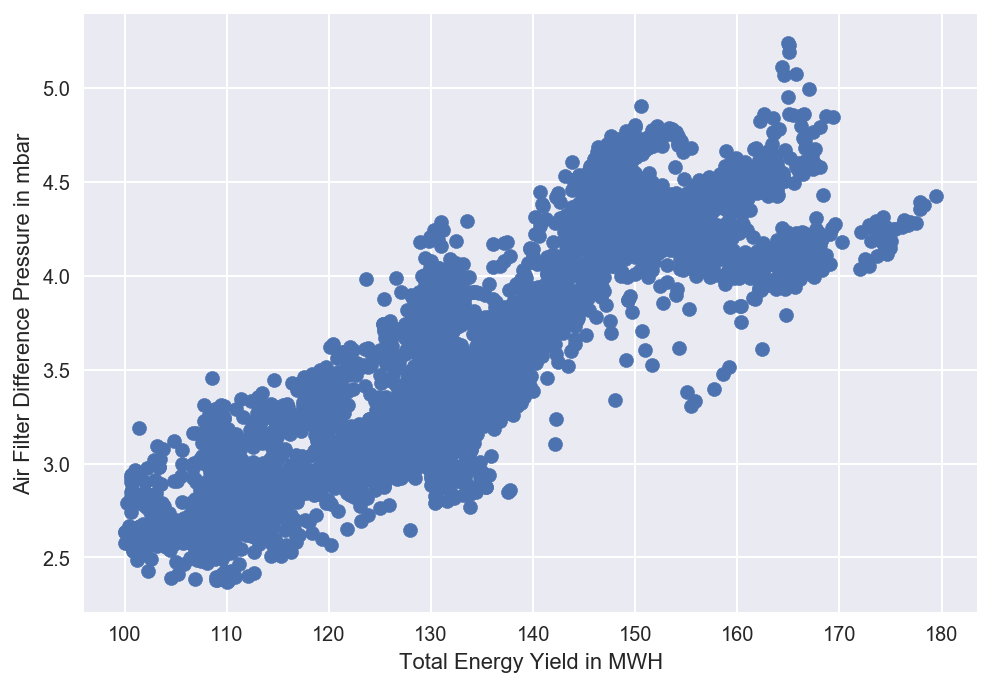

```python
#Scatter plot between TEY and AFDP
plt.scatter(GT_emissions['TEY'], GT_emissions['AFDP'])
plt.xlabel('Total Energy Yield in MWH')
plt.ylabel('Air Filter Difference Pressure in mbar')
```

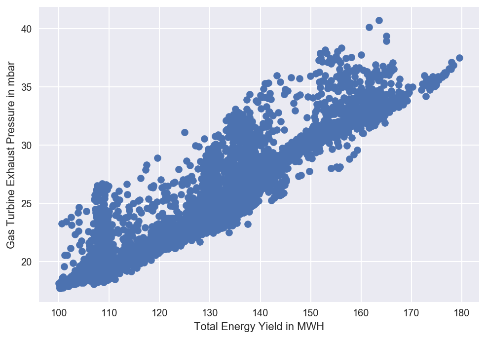

```python
#Scatter plot between TEY and GTEP
plt.scatter(GT_emissions['TEY'], GT_emissions['GTEP'])
plt.xlabel('Total Energy Yield in MWH')
plt.ylabel('Gas Turbine Exhaust Pressure in mbar')
```

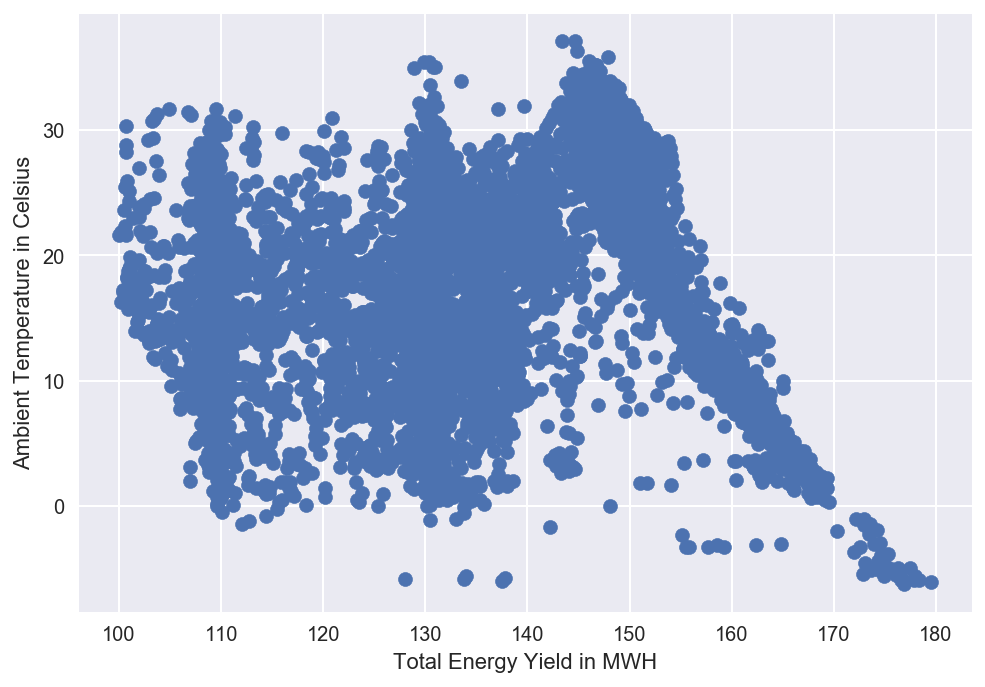

```python
#Scatter plot between TEY and AT
plt.scatter(GT_emissions['TEY'], GT_emissions['AT'])
plt.xlabel('Total Energy Yield in MWH')
plt.ylabel('Ambient Temperature in Celsius')
```

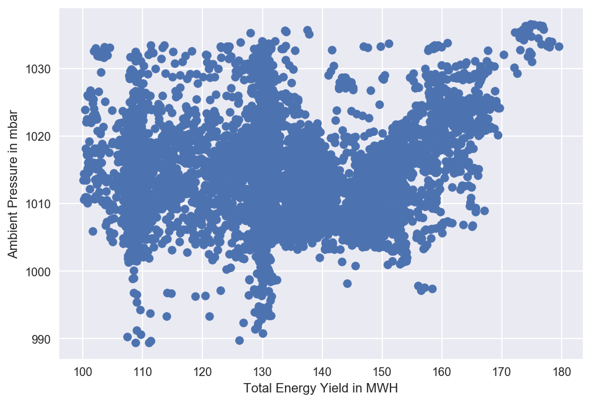

```python
#Scatter plot between TEY and AP
plt.scatter(GT_emissions['TEY'], GT_emissions['AP'])
plt.xlabel('Total Energy Yield in MWH')
plt.ylabel('Ambient Pressure in mbar')
```

From the plots above, we can see that TEY is heavily correlated with AFDP, CDP, GTEP and TIT. A weak correaltion can be seen between TEY with AT and AP. Looking at the plots, it is safe to say that the total energy yield does not depend heavily on the ambient temperature or the ambient pressure. To further understand this data, let us look at a heatmap which will give us a better idea about the correlation between the variables.

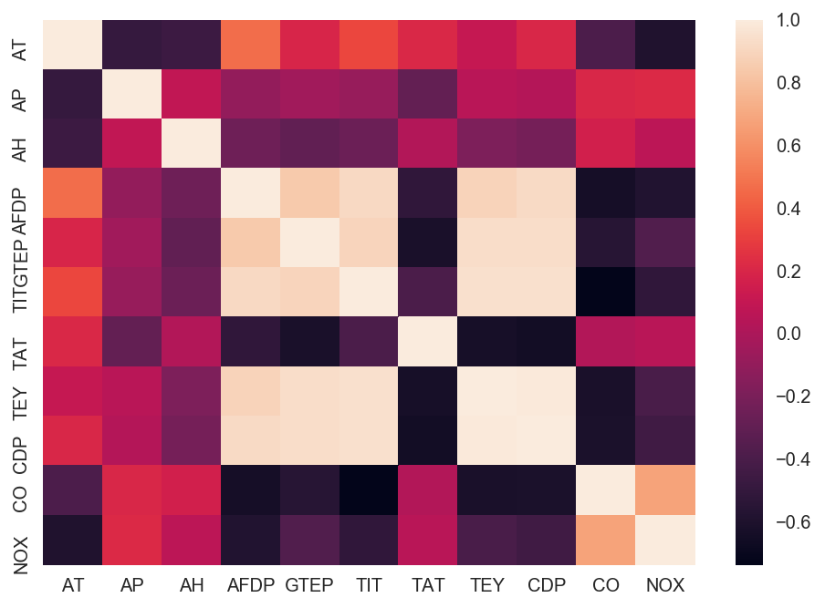

```python
sns.heatmap(GT_emissions.corr())
```

The heatmap only confirms what we have seen in the bivariate analysis. TEY has a very high correlation with CDP, TIT, GTEP, and AFDP. We can also see some weak correlation between TEY and AT.

## Conclusions

Data cleaning, data preprocessing, and data visualisation was used in Phase 1 of this project. Starting the phase 1 of the project with identifying the target variable, we checked for the data types of all the variables present in the dataset. Further, the summary statistics gave a deeper insight about the data. The summary statistics was also used to identify any missing or null values that might be present in the dataset. We found out that the dataset did not have any null/missing values.

Exploratory data analysis was done using visual plots. It was found that a similar patter was being observed for a few of the variables such as TEY and CDP, suggesting that they might have a high correlation. Boxplots were plotted to check for any outliers. Some outliers were found in the variable Turbine Inlet Temperature (TIT). The outliers were dealt with by using the drop operator. Moving on to the bivariate plots, we saw that there was a very high correlation of variables such as Compressor Discharge Pressure (CDP), Gas Turbine Exhaust Pressure (GTEP) and a few other variables with Total Energy Yield (TEY); which is our target variable.

Some variables like the Turbine Inlet temperature (TIT) appears to be skewed. The others are also not following a normal distribution. More analysis is to be conducted to understand the data better.

## References

- Heysem Kaya.Gas Turbine CO and NOx Emission Data Set Data Set.Retrieved April 8, 2021 from https://archive.ics.uci.edu/ml/datasets/Gas+Turbine+CO+and+NOx+Emission+Data+Set